# Overview

### Helper Functions

```python
### General Functions ###

def mkdir(*args):
    """
    To create directory for a given path
    """
    path = os.path.join(*args)
    try:
        os.makedirs(path)
    except OSError:
        if not os.path.isdir(path):
            raise
    return path

def neat_print_sperator(name):
    """
    A function to create sperations between displays and prints
    """
    spacing_len = 95 - len(name)
    print('{} {} {}'.format('_'*math.floor((spacing_len/2)), name, '_'*math.ceil(spacing_len/2)))
    return
```

```python
### Dataframe related functions ###

def load_dataframe(file_path, file_type = "csv"):
    """
    A function to load datasets in csv/xlsx format
    """
    if file_type=="csv":
        df = pd.read_csv(file_path, index_col = None, encoding = "ISO-8859-1")
    elif file_type=="xlsx":
        df = pd.read_excel(file_path, index_col = None, encoding = "ISO-8859-1")
    return df

def save_dataframe(data_frame, file_path, file_type = "csv"):
    if file_type=="csv":
        data_frame.to_csv(file_path, index = False)
    elif file_type=="xlsx":
        data_frame.to_xlsx(file_path, index = False)

def gradient_dataframe(df, caption):
    """
    Converting dataframe into Gradient DataFrame
    """

    agg_df = df.style.set_table_styles(
            [{'selector': 'tr:nth-of-type(odd)',
              'props': [('background', '#eee'),
                       ('text-align', 'left')]},
             {'selector': 'tr:nth-of-type(even)',
              'props': [('background', 'white'), ('text-align', 'left')]},
             {'selector': 'th',
              'props': [('background', '#808080'),
                        ('color', 'white'),
                        ('font-family', 'verdana'),
                       ('text-align', 'left')]},
             {'selector': 'td',
              'props': [('font-family', 'verdana'), ('text-align', 'left')]},
            ]
            ).hide_index().format(formatter=None).set_caption(f'{caption}')\
                .background_gradient(cmap='Blues')
    return agg_df

def missing_value_of_data(data):
    """
    Function to find out missing values in the dataset
    """
    total=data.isnull().sum().sort_values(ascending=False)
    percentage=np.round(total/data.shape[0]*100,2)
    return pd.concat([total,percentage],axis=1,keys=['Total','Percentage'])
```

```python
### Plotly related functions ###

def plotly_bar_pie_chart(cnt_srs, layout_title, pie_title):
    """
    Plotly function to Plot Bar & Pie Charts
    """

    trace = go.Bar(
        x=cnt_srs.index,
        y=cnt_srs.values,
        marker=dict(
            color=cnt_srs.values,
            colorscale = 'Picnic',
            reversescale = True
        ),
    )

    layout = go.Layout(
        title=layout_title,
        font=dict(size=12)
    )

    data = [trace]
    fig = go.Figure(data=data, layout=layout)
    fig.update_xaxes(showline=True, linewidth=2, linecolor='black', mirror=True)
    py.iplot(fig, filename=pie_title)

    ## target distribution ##
    labels = (np.array(cnt_srs.index))
    sizes = (np.array((cnt_srs / cnt_srs.sum())*100))

    trace = go.Pie(labels=labels, values=sizes)
    layout = go.Layout(
        title=pie_title,
        font=dict(size=12)
    )
    data = [trace]
    fig = go.Figure(data=data, layout=layout)
    fig.update_xaxes(showline=True, linewidth=2, linecolor='black', mirror=True)
    py.iplot(fig, filename="usertype")

def horizontal_bar_chart(df, color):
    """
    Custom function for Horizontal Bar Chart
    """
    trace = go.Bar(
        y=df["word"].values[::-1],
        x=df["wordcount"].values[::-1],
        showlegend=False,
        orientation = 'h',
        marker=dict(
            color=color,
        ),
    )
    return trace

def plotly_box_plot(X, Y, caption, color):
    """
    Custom function for Box Plot
    """
    data = [go.Box(
            y=Y,
            x=X,
            showlegend=False,
            marker= dict(color=color)
        )]

    layout = go.Layout(
        title=caption
    )

    fig = go.Figure(data=data, layout=layout)
    fig.update_xaxes(showline=True, linewidth=2, linecolor='black', mirror=True)
    py.iplot(fig, filename='basic-box')

def plotly_histogram_chart(X, x_title, color):
    """
    Histogram chart of Continuous variable using Plotly
    """
    fig = go.Figure()
    fig.add_trace(go.Histogram(x=X, marker_color=color))
    # Overlay both histograms
    fig.update_xaxes(showline=True, linewidth=2, linecolor='black', mirror=True)
    fig.update_layout(
        title_text=f"Restaurant's {x_title} Distribution", # title of plot
        xaxis_title_text=x_title, # xaxis label
        yaxis_title_text='Count', # yaxis label
        title_x=0.5,
        barmode='overlay')

    # Reduce opacity to see both histograms
    fig.update_traces(opacity=0.75)
    fig.show()

def plotly_bubble_chart(X, Y, label):
    """
    Bubble chart using Plotly
    """
    fig = go.Figure(data=go.Scatter(
                    x=X,
                    y=Y,
                    hovertext = label,
                    mode='markers',
                    marker=dict(
                         color='rgb(255, 178, 102)',
                         size=10,
                         line=dict(
                            color='DarkSlateGrey',
                            width=1
                          )
                   )
    ))

    fig.update_xaxes(showline=True, linewidth=2, linecolor='black', mirror=True)
    fig.update_layout(
        title=f'Rating vs # Votes vs Cost',
        xaxis_title='Rating',
        yaxis_title='# Votes'
    )
    fig.show()

def plot_wordcloud(text, mask=None, max_words=200, max_font_size=100, figure_size=(24.0,16.0),
                   title = None, title_size=40, image_color=False):
    """Function to Plot Word Clouds"""

    stopwords = set(STOPWORDS)
    more_stopwords = {'one', 'br', 'Po', 'th', 'sayi', 'fo', 'Unknown'}
    stopwords = stopwords.union(more_stopwords)

    wordcloud = WordCloud(background_color='black',
                    stopwords = stopwords,
                    max_words = max_words,
                    max_font_size = max_font_size,
                    random_state = 42,
                    width=800,
                    height=400,
                    mask = mask)
    wordcloud.generate(str(text))

    plt.figure(figsize=figure_size)
    if image_color:
        image_colors = ImageColorGenerator(mask);
        plt.imshow(wordcloud.recolor(color_func=image_colors), interpolation="bilinear");
        plt.title(title, fontdict={'size': title_size,
                                  'verticalalignment': 'bottom'})
    else:
        plt.imshow(wordcloud);
        plt.title(title, fontdict={'size': title_size, 'color': 'black',
                                  'verticalalignment': 'bottom'})
    plt.axis('off');
    plt.tight_layout()
```

```python
### Text Pre-Processing Related Functions ###
def lemmatize_words(text):
    pos_tagged_text = nltk.pos_tag(text.split())
    return " ".join([lemmatizer.lemmatize(word, wordnet_map.get(pos[0], wordnet.NOUN)) for word, pos in pos_tagged_text])

def generate_ngrams(text, n_gram=1):
    """
    Custom function for ngram generation
    """
    token = [token for token in str(text).lower().split(" ") if token != "" if token not in STOPWORDS]
    ngrams = zip(*[token[i:] for i in range(n_gram)])
    return [" ".join(ngram) for ngram in ngrams]

def gensim_clean_text(s):
    """
    Clean the text using Gensim library
    """
    filters = [
               gsp.strip_tags,
               gsp.strip_punctuation,
               gsp.strip_multiple_whitespaces,
               gsp.strip_numeric,
               gsp.remove_stopwords,
               gsp.strip_short
              ]
    s = str(s).lower()
    s = utils.to_unicode(s)
    s = re.sub(r'[^\x00-\x7F]+',' ', s)
    s = re.sub('https?://\S+|www\.\S+', '', s)
    s = re.sub('\n', '', s)
    s = lemmatize_words(s)
    for f in filters:
        s = f(s)
    return s
```

### Main Functions

```python
def run_xgb(train_X, train_y, test_X, test_y=None, feature_names=None, seed_val=2017, num_rounds=500):
    """
    Function to Run XGBoost Model (Binary Classification)
    """
    param = {}
    param['objective'] = 'binary:logistic'
    param['eta'] = 0.1
    param['max_depth'] = 6
    param['silent'] = 1
    param['eval_metric'] = 'auc'
    param['min_child_weight'] = 1
    param['subsample'] = 0.7
    param['colsample_bytree'] = 0.7
    param['seed'] = seed_val
    num_rounds = num_rounds

    plst = list(param.items())
    xgtrain = xgb.DMatrix(train_X, label=train_y)

    if test_y is not None:
        xgtest = xgb.DMatrix(test_X, label=test_y)
        watchlist = [ (xgtrain,'train'), (xgtest, 'test') ]
        model = xgb.train(plst, xgtrain, num_rounds, watchlist, early_stopping_rounds=20)
    else:
        xgtest = xgb.DMatrix(test_X)
        model = xgb.train(plst, xgtrain, num_rounds)

    return model
```

```python
def predictions_scores(preds, test, category):
    """Function to generate Classification Report"""
    print(f"######################## {category} #############################")
    threshold_values = [0.1, 0.15, 0.2, 0.25, 0.3, 0.35, 0.4, 0.45, 0.5, 0.55, 0.6, 0.65, 0.7, 0.75, 0.8, 0.85, 0.9, 0.95]
    for threshold in threshold_values:
        print("Threshold {} : ".format(threshold))
        # calculating test accuracy
        prediction = [1 if x > threshold else 0 for x in preds[category]]
        print('Test accuracy is {}'.format(accuracy_score(test[category], prediction)))
        false_positive_rate, true_positive_rate, thresholds = roc_curve(test[category], preds[category])
        print("\nAUC Score: ", auc(false_positive_rate, true_positive_rate))
        print('\nClasification report:\n', classification_report(test[category], prediction))
        print("\n")
```

### Directory Setup

```python
"""
Get the working directory
"""
WORKING_DIR = os.getcwd()
```

```python
"""
Create raw, processed, cleaned directory in data directory
"""
DATA_DIR = mkdir(WORKING_DIR, "data")
RAW_DIR = os.path.join(DATA_DIR, "raw") # All raw data will be present here
PROCESSED_DIR = mkdir(os.path.join(WORKING_DIR, DATA_DIR.split("\\")[-1]), "processed") # All processed data will be here
CLEANED_DIR = mkdir(os.path.join(WORKING_DIR, DATA_DIR.split("\\")[-1]), "cleaned") # All cleaned data will be here
```

```python
#################################################################################################
# Create output data directory:
#################################################################################################
OUTPUT_DIR = mkdir(WORKING_DIR, "outputs")
```

### Data Preparation & Exploration

#### Load Datasets

```python
"""
Load Fake News Training, Testing and Submission Dataset
"""
train_df = load_dataframe(os.path.join(RAW_DIR, "train.csv"))
test_df = load_dataframe(os.path.join(RAW_DIR, "test.csv"))
sub_df = load_dataframe(os.path.join(RAW_DIR, "submit.csv"))

print("There are {} Rows and {} Columns in Training Dataset".format(train_df.shape[0], train_df.shape[1]))
print("There are {} Rows and {} Columns in Testing Dataset".format(test_df.shape[0], test_df.shape[1]))
print("There are {} Rows and {} Columns in Submission Dataset".format(sub_df.shape[0], sub_df.shape[1]))

print(100*"*")

## Remove Duplicate Rows (if any)
train_df.drop_duplicates(inplace = True)
test_df.drop_duplicates(inplace = True)
sub_df.drop_duplicates(inplace = True)

print("There are {} Rows and {} Columns in Training Dataset After Removing Duplicates".format(train_df.shape[0], train_df.shape[1]))
print("There are {} Rows and {} Columns in Testing Dataset After Removing Duplicates".format(test_df.shape[0], test_df.shape[1]))
print("There are {} Rows and {} Columns in Submission Dataset After Removing Duplicates".format(sub_df.shape[0], sub_df.shape[1]))
```

```
There are 20800 Rows and 5 Columns in Training Dataset
There are 5200 Rows and 4 Columns in Testing Dataset
There are 5200 Rows and 2 Columns in Submission Dataset
There are 20800 Rows and 5 Columns in Training Dataset After Removing Duplicates
There are 5200 Rows and 4 Columns in Testing Dataset After Removing Duplicates
There are 5200 Rows and 2 Columns in Submission Dataset After Removing Duplicates
```

It is clear from above cell that there are no duplicates (rows) in fake news data. Next, let us look at top rows of dataframe:

```python
gradient_dataframe(train_df.head(2), "Top 2 rows of Training dataset")
```

Top 2 rows of Training dataset

| id | title | author | text | label |
| --- | --- | --- | --- | --- |
| 0 | House Dem Aide: We Didnât Even See Comeyâs Letter Until Jason Chaffetz Tweeted It | Darrell Lucus | House Dem Aide: We Didnât Even See Comeyâs Letter Until Jason Chaffetz Tweeted It By Darrell Lucus on October 30, 2016 Subscribe Jason Chaffetz on the stump in American Fork, Utah ( image courtesy… | 1 |
| 1 | FLYNN: Hillary Clinton, Big Woman on Campus - Breitbart | Daniel J. Flynn | Ever get the feeling your life circles the roundabout rather than heads in a straight line toward the intended destination? [Hillary Clinton remains the big woman on campus in leafy, liberal Wellesley… | 0 |

```python
"""
Check datatypes of all the features
"""
data_type_df = pd.DataFrame(train_df.dtypes).reset_index().rename(columns = {'index':'Columns', 0:'Data Type'})
gradient_dataframe(data_type_df, caption="Data Types in Fake news training Dataset")
```

Data Types in Fake news training Dataset

| Columns | Data Type |
| --- | --- |
| id | int64 |
| title | object |
| author | object |
| text | object |
| label | int64 |

#### Missing Value Count

```python
train_miss_df = missing_value_of_data(train_df)
train_miss_df = train_miss_df.reset_index()
train_miss_df.rename(columns = {'index':'Columns'}, inplace = True)
gradient_dataframe(train_miss_df, caption="Missing values for Training Dataset")
```

Missing values for Training Dataset

| Columns | Total | Percentage |
| --- | --- | --- |
| author | 1957 | 9.410000 |
| title | 558 | 2.680000 |
| text | 39 | 0.190000 |
| label | 0 | 0.000000 |
| id | 0 | 0.000000 |

**Key Takeaway:** `author (9.4 %)`, `title (2.68 %)`, `text (0.19 %)` features contains missing values in training dataset

```python
test_miss_df = missing_value_of_data(test_df)
test_miss_df = test_miss_df.reset_index()
test_miss_df.rename(columns = {'index':'Columns'}, inplace = True)
gradient_dataframe(test_miss_df, caption="Missing values for Testing Dataset")
```

Missing values for Testing Dataset

| Columns | Total | Percentage |
| --- | --- | --- |
| author | 503 | 9.670000 |
| title | 122 | 2.350000 |
| text | 7 | 0.130000 |
| id | 0 | 0.000000 |

**Key Takeaway:** `author (9.67 %)`, `title (2.35 %)`, `text (0.13 %)` features contains missing values in testing dataset

#### Data Cleaning

```python
"""
Cleaning Text Columns for Training & Testing datasets using gensim_clean_text function
"""
train_df['clean_text'] = train_df['text'].apply(lambda x:gensim_clean_text(x))
train_df['clean_title'] = train_df['title'].apply(lambda x:gensim_clean_text(x))
train_df['clean_author'] = train_df['author'].apply(lambda x:gensim_clean_text(x))

test_df['clean_text'] = test_df['text'].apply(lambda x:gensim_clean_text(x))
test_df['clean_title'] = test_df['title'].apply(lambda x:gensim_clean_text(x))
test_df['clean_author'] = test_df['author'].apply(lambda x:gensim_clean_text(x))
```

#### Data Exploration

##### Target Variable Distribution

```python
target_cnt_srs = train_df['label'].value_counts().sort_values(ascending=False)
plotly_bar_pie_chart(target_cnt_srs, layout_title="Count of Fake (1)/Real (0) News Articles",
                    pie_title="Fake (1)/Real(0) News Articles Distribution")
```

[interactive chart not shown]

**Key Takeaway:** Fake (1)/ Real (0) are almost equally distributed

##### Most Popular Authors of News Articles

```python
author_cnt_srs = train_df['author'].value_counts().sort_values(ascending=False).head(10)
plotly_bar_pie_chart(author_cnt_srs, layout_title="Count of Top 10 Authors of news articles",
                    pie_title="Top 10 Authors of news articles")
```

[interactive chart not shown]

**Key Takeaway:** `Pam Key` is the most popular author of news articles (16.4%, 243)

##### Distribution of Number of Words

```python
dist_train_df = train_df[["title", "text"]]

dist_train_df['num_words_title'] = dist_train_df['title'].apply(lambda x:len(str(x).split())) #Number Of words in title Text
dist_train_df['num_word_text'] = dist_train_df['text'].apply(lambda x:len(str(x).split())) #Number Of words in main text
dist_train_df['difference_in_words'] = dist_train_df['num_word_text'] - dist_train_df['num_words_title'] #Difference in Number of words text and title Text

hist_data = [dist_train_df['num_words_title'], dist_train_df['num_word_text']]

group_labels = ['Title', 'Text']

# Create distplot with custom bin_size
fig = ff.create_distplot(hist_data, group_labels,show_curve=False)
fig.update_layout(title_text='Distribution of Number Of words')
fig.update_layout(
    autosize=False,
    width=900,
    height=700,
    paper_bgcolor="LightSteelBlue",
)
fig.show()
```

[interactive chart not shown]

**Key Takeaway:** text having number of words greater than 10K are very less and thus the number of words distribution plot is right skewed

##### Most Common Words - In Title

```python
## Get the bar chart from 1st Class ##
freq_dict = defaultdict(int)
for sent in train_df["clean_title"]:
    for word in generate_ngrams(sent, 1):
        freq_dict[word] += 1
fd_sorted = pd.DataFrame(sorted(freq_dict.items(), key=lambda x: x[1])[::-1])
fd_sorted.columns = ["word", "wordcount"]
trace0 = horizontal_bar_chart(fd_sorted.head(50), 'blue')

## Get the bar chart from 2nd Class ##
freq_dict = defaultdict(int)
for sent in train_df["clean_title"]:
    for word in generate_ngrams(sent, 2):
        freq_dict[word] += 1
fd_sorted = pd.DataFrame(sorted(freq_dict.items(), key=lambda x: x[1])[::-1])
fd_sorted.columns = ["word", "wordcount"]
trace1 = horizontal_bar_chart(fd_sorted.head(50), 'orange')

# Creating two subplots
fig = tools.make_subplots(rows=1, cols=2, vertical_spacing=0.04,
                          subplot_titles=["Frequent Unigrams in Title of Articles",
                                          "Frequent Bigrams in Title of Articles"])
fig.append_trace(trace0, 1, 1)
fig.append_trace(trace1, 1, 2)
fig['layout'].update(height=1200, width=900, paper_bgcolor='rgb(233,233,233)', title="Word Count Plots")
py.iplot(fig, filename='word-plots')
```

[interactive chart not shown]

```python
## Get the bar chart from 1st Class ##
freq_dict = defaultdict(int)
for sent in train_df["clean_title"]:
    for word in generate_ngrams(sent, 3):
        freq_dict[word] += 1
fd_sorted = pd.DataFrame(sorted(freq_dict.items(), key=lambda x: x[1])[::-1])
fd_sorted.columns = ["word", "wordcount"]
trace0 = horizontal_bar_chart(fd_sorted.head(50), 'red')

# Creating two subplots
fig = tools.make_subplots(rows=1, cols=1, vertical_spacing=0.04,
                          subplot_titles=["Frequent Trigrams in Title of Articles"])
fig.append_trace(trace0, 1, 1)
fig['layout'].update(height=1200, width=900, paper_bgcolor='rgb(233,233,233)', title="Word Count Plots")
py.iplot(fig, filename='word-plots')
```

[interactive chart not shown]

##### Most Common Words - In Text

```python
## Get the bar chart from 1st Class ##
freq_dict = defaultdict(int)
for sent in train_df["clean_text"].fillna(""):
    for word in generate_ngrams(sent, 1):
        freq_dict[word] += 1
fd_sorted = pd.DataFrame(sorted(freq_dict.items(), key=lambda x: x[1])[::-1])
fd_sorted.columns = ["word", "wordcount"]
trace0 = horizontal_bar_chart(fd_sorted.head(50), 'blue')

## Get the bar chart from 2nd Class ##
freq_dict = defaultdict(int)
for sent in train_df["clean_text"].fillna(""):
    for word in generate_ngrams(sent, 2):
        freq_dict[word] += 1
fd_sorted = pd.DataFrame(sorted(freq_dict.items(), key=lambda x: x[1])[::-1])
fd_sorted.columns = ["word", "wordcount"]
trace1 = horizontal_bar_chart(fd_sorted.head(50), 'orange')

# Creating two subplots
fig = tools.make_subplots(rows=1, cols=2, vertical_spacing=0.04,
                          subplot_titles=["Frequent Unigrams in Text of Articles",
                                          "Frequent Bigrams in Text of Articles"])
fig.append_trace(trace0, 1, 1)
fig.append_trace(trace1, 1, 2)
fig['layout'].update(height=1200, width=900, paper_bgcolor='rgb(233,233,233)', title="Word Count Plots")
py.iplot(fig, filename='word-plots')
```

[interactive chart not shown]

```python
## Get the bar chart from 1st Class ##
freq_dict = defaultdict(int)
for sent in train_df["clean_text"].fillna(""):
    for word in generate_ngrams(sent, 3):
        freq_dict[word] += 1
fd_sorted = pd.DataFrame(sorted(freq_dict.items(), key=lambda x: x[1])[::-1])
fd_sorted.columns = ["word", "wordcount"]
trace0 = horizontal_bar_chart(fd_sorted.head(50), 'red')

# Creating two subplots
fig = tools.make_subplots(rows=1, cols=1, vertical_spacing=0.04,
                          subplot_titles=["Frequent Trigrams in Text of Articles"])
fig.append_trace(trace0, 1, 1)
fig['layout'].update(height=1200, width=900, paper_bgcolor='rgb(233,233,233)', title="Word Count Plots")
py.iplot(fig, filename='word-plots')
```

[interactive chart not shown]

##### WordCloud of News Articles Text

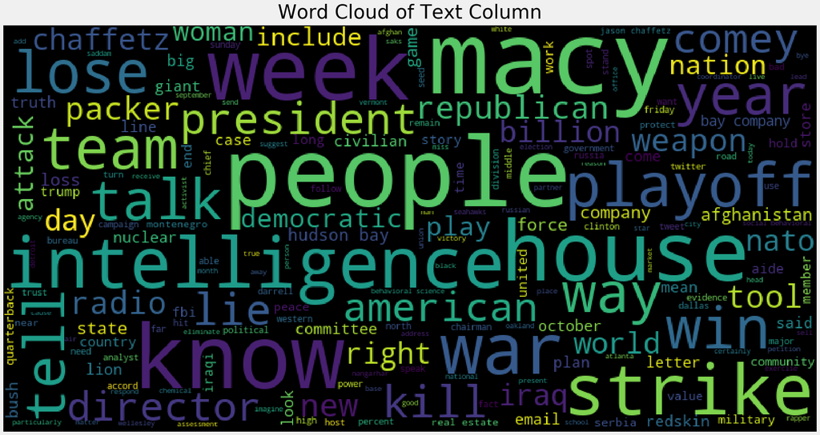

```python
plot_wordcloud(train_df["clean_text"], title="Word Cloud of Text Column")
```

##### WordCloud of News Articles Title

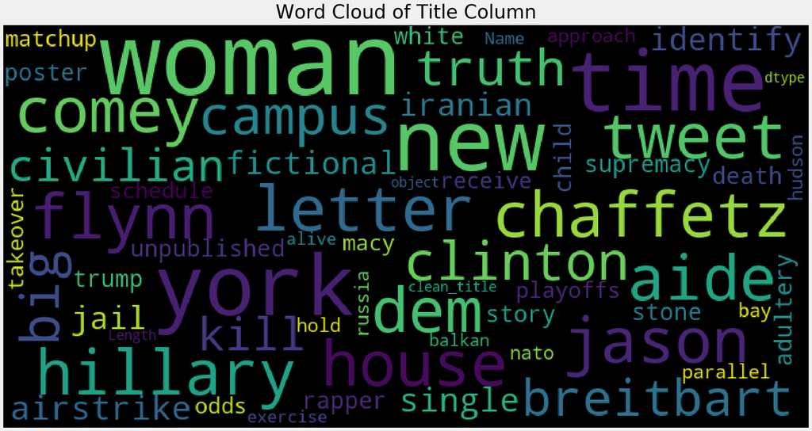

```python
plot_wordcloud(train_df["clean_title"], title="Word Cloud of Title Column")
```

**Key Takeaway:** `woman`, `Hillary Clinton` etc. are mostly written words in title of news articles

#### Data Preparation for ML Modeling

```python
"""
Let's Combine "Title", "Author", "Text" Column for both train & test datasets
"""
## Without Cleaned
train_df["combined_title_text"] = train_df["title"].fillna("nan") + " " + train_df["author"].fillna("nan") + " " + train_df["text"].fillna("nan")
test_df["combined_title_text"] = test_df["title"].fillna("nan") + " " + test_df["author"].fillna("nan") + " " +  test_df["text"].fillna("nan")

## With Cleaned
train_df["combined_clean_title_text"] = train_df["clean_title"] + " " + train_df["clean_author"] + " " + train_df["clean_text"]
test_df["combined_clean_title_text"] = test_df["clean_title"] + " " + test_df["clean_author"] + " " +  test_df["clean_text"]
```

```python
"""
Let's save processed datasets
"""
save_dataframe(train_df, os.path.join(PROCESSED_DIR, "train_processed_df.csv"))
save_dataframe(test_df, os.path.join(PROCESSED_DIR, "test_processed_df.csv"))
```

```python
"""
Train & Test Split using Scikit Learn train_test_split function
"""
X_train, X_test, y_train, y_test = train_test_split(train_df[["combined_title_text", "combined_clean_title_text"]],
                                                    train_df["label"],
                               test_size=0.2, random_state=2)
print("# Rows in Train data: ", X_train.shape[0])
print("# Rows in Test data: ", X_test.shape[0])
```

```
# Rows in Train data:  16640
# Rows in Test data:  4160
```

```python
"""
Let's save cleaned (train & test) datasets
"""
save_dataframe(X_train, os.path.join(CLEANED_DIR, "train_cleaned_df.csv"))
save_dataframe(X_test, os.path.join(CLEANED_DIR, "test_cleaned_df.csv"))
```

#### TF-IDF Vectorization

```python
# =============================================================================
# Applying TfidfVectorizer on "text" column of train data
# =============================================================================

transform_tfidf = TfidfVectorizer(ngram_range=(1,3), # ngrams - unigram to trigram
                                min_df=3, # removing terms that appear too infrequently
                                max_df=0.9, # removing terms that appear too frequently
                                strip_accents='unicode', # unicode characters
                                use_idf=1, # Enable inverse-document-frequency reweighting
                                smooth_idf=1, # Smooth idf weights by adding one to document frequencies
                                sublinear_tf=1).fit(X_train["combined_clean_title_text"]) # Apply sublinear tf scaling; replace tf with 1 + log(tf).
```

```python
# =============================================================================
# Transforming training & testing data
# =============================================================================

train_transform = transform_tfidf.transform(X_train["combined_clean_title_text"]) # Transforming training data
test_transform = transform_tfidf.transform(X_test["combined_clean_title_text"]) # Transforming validation data
sub_transform = transform_tfidf.transform(test_df['combined_clean_title_text']) # Transforming test data
```

### Text Classification (TF-IDF) & Kaggle Leaderboard Scores

#### Logistic Regression

```python
model_log = LogisticRegression(random_state=0).fit(train_transform, y_train)
```

```python
###############################################################################################################
# Prediction on Validation set to check the threshold:
###############################################################################################################
prob_validation = model_log.predict(test_transform)
prob_validation = pd.DataFrame(prob_validation, columns = ["label"])
```

```python
###############################################################################################################
# Confusion Matrix:
###############################################################################################################
predictions_scores(prob_validation, pd.DataFrame(y_test, columns = ["label"]), "label") # 0.50
```

```python
###############################################################################################################
# Prediction on Test set
###############################################################################################################

prob_test = model_log.predict(sub_transform)

# Apply threshold :

prob_test = [1 if pred > 0.5 else 0 for pred in prob_test]
prob_test = pd.DataFrame(prob_test, columns = ["label"])


sub_test_df = pd.concat([test_df["id"], prob_test["label"]], axis=1)
sub_final_df = pd.merge(sub_df["id"], sub_test_df, how = "left").fillna(1)
```

```python
save_dataframe(sub_final_df, os.path.join(OUTPUT_DIR,"submit_log_tfidf.csv"))
```

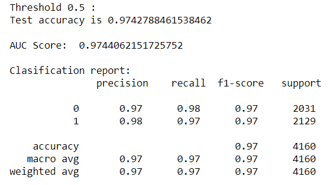

```python
Image(filename=os.path.join(OUTPUT_DIR,"log_tfidf_report.png"))
```

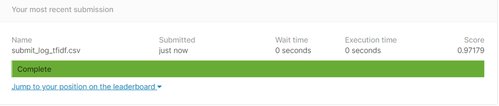

```python
Image(filename=os.path.join(OUTPUT_DIR,"submit_log_tfidf.png"))
```

#### Decision Tree

```python
model_dec = DecisionTreeClassifier(random_state=0).fit(train_transform, y_train)
```

```python
###############################################################################################################
# Prediction on Validation set to check the threshold:
###############################################################################################################
prob_validation = model_dec.predict(test_transform)
prob_validation = pd.DataFrame(prob_validation, columns = ["label"])
```

```python
###############################################################################################################
# Confusion Matrix:
###############################################################################################################
predictions_scores(prob_validation, pd.DataFrame(y_test, columns = ["label"]), "label") # 0.50
```

```python
###############################################################################################################
# Prediction on Test set
###############################################################################################################

prob_test = model_dec.predict(sub_transform)

# Apply threshold :

prob_test = [1 if pred > 0.5 else 0 for pred in prob_test]
prob_test = pd.DataFrame(prob_test, columns = ["label"])


sub_test_df = pd.concat([test_df["id"], prob_test["label"]], axis=1)
sub_final_df = pd.merge(sub_df["id"], sub_test_df, how = "left").fillna(1)
```

```python
save_dataframe(sub_final_df, os.path.join(OUTPUT_DIR,"submit_dt_tfidf.csv"))
```

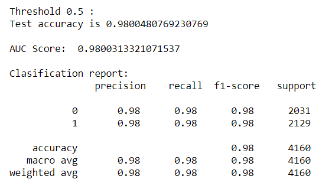

```python
Image(filename=os.path.join(OUTPUT_DIR,"dt_tfidf_report.png"))
```

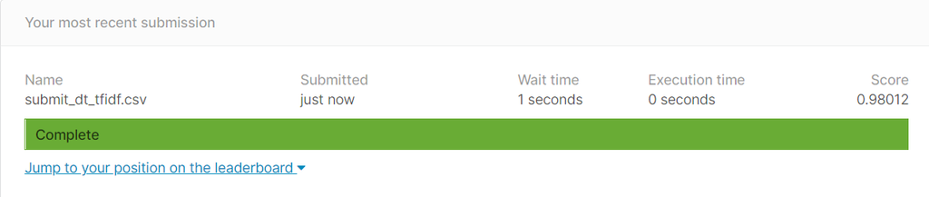

```python
Image(filename=os.path.join(OUTPUT_DIR,"submit_dt_tfidf.png"))
```

#### Random Forest

```python
model_rf = RandomForestClassifier(random_state=0).fit(train_transform, y_train)
```

```python
###############################################################################################################
# Prediction on Validation set to check the threshold:
###############################################################################################################
prob_validation = model_rf.predict(test_transform)
prob_validation = pd.DataFrame(prob_validation, columns = ["label"])
```

```python
###############################################################################################################
# Confusion Matrix:
###############################################################################################################
predictions_scores(prob_validation, pd.DataFrame(y_test, columns = ["label"]), "label") # 0.50
```

```python
###############################################################################################################
# Prediction on Test set
###############################################################################################################

prob_test = model_rf.predict(sub_transform)

# Apply threshold :

prob_test = [1 if pred > 0.5 else 0 for pred in prob_test]
prob_test = pd.DataFrame(prob_test, columns = ["label"])


sub_test_df = pd.concat([test_df["id"], prob_test["label"]], axis=1)
sub_final_df = pd.merge(sub_df["id"], sub_test_df, how = "left").fillna(1)
```

```python
save_dataframe(sub_final_df, os.path.join(OUTPUT_DIR,"submit_rf_tfidf.csv"))
```

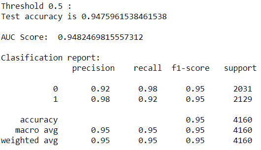

```python
Image(filename=os.path.join(OUTPUT_DIR,"rf_tfidf_report.png"))
```

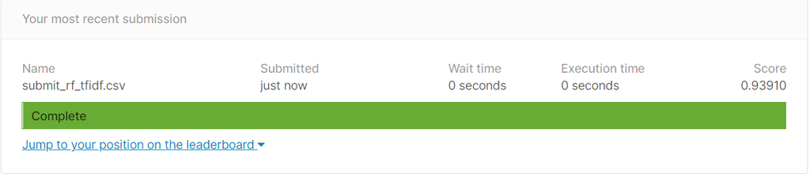

```python
Image(filename=os.path.join(OUTPUT_DIR,"submit_rf_tfidf.png"))
```

#### Gradient Boosting Classifier

```python
model_gbm = GradientBoostingClassifier(random_state=0).fit(train_transform, y_train)
```

```python
###############################################################################################################
# Prediction on Validation set to check the threshold:
###############################################################################################################
prob_validation = model_gbm.predict(test_transform)
prob_validation = pd.DataFrame(prob_validation, columns = ["label"])
```

```python
###############################################################################################################
# Confusion Matrix:
###############################################################################################################
predictions_scores(prob_validation, pd.DataFrame(y_test, columns = ["label"]), "label") # 0.50
```

```python
###############################################################################################################
# Prediction on Test set
###############################################################################################################

prob_test = model_gbm.predict(sub_transform)

# Apply threshold :

prob_test = [1 if pred > 0.5 else 0 for pred in prob_test]
prob_test = pd.DataFrame(prob_test, columns = ["label"])


sub_test_df = pd.concat([test_df["id"], prob_test["label"]], axis=1)
sub_final_df = pd.merge(sub_df["id"], sub_test_df, how = "left").fillna(1)
```

```python
save_dataframe(sub_final_df, os.path.join(OUTPUT_DIR,"submit_gbm_tfidf.csv"))
```

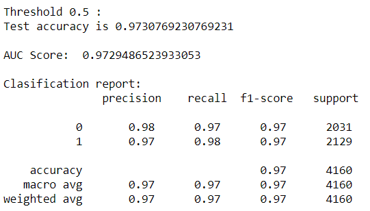

```python
Image(filename=os.path.join(OUTPUT_DIR,"gbm_tfidf_report.png"))
```

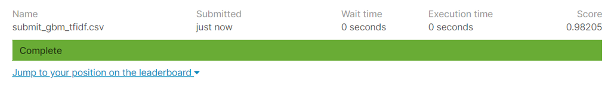

```python
Image(filename=os.path.join(OUTPUT_DIR,"submit_gbm_tfidf.png"))
```

#### LightGBM (Best Score)

```python
model_lgb = lgb.LGBMClassifier(random_state=0).fit(train_transform, y_train)
```

```python
###############################################################################################################
# Prediction on Validation set to check the threshold:
###############################################################################################################
prob_validation = model_lgb.predict(test_transform)
prob_validation = pd.DataFrame(prob_validation, columns = ["label"])
```

```python
###############################################################################################################
# Confusion Matrix:
###############################################################################################################
predictions_scores(prob_validation, pd.DataFrame(y_test, columns = ["label"]), "label") # 0.50
```

```python
###############################################################################################################
# Prediction on Test set
###############################################################################################################

prob_test = model_lgb.predict(sub_transform)

# Apply threshold :

prob_test = [1 if pred > 0.5 else 0 for pred in prob_test]
prob_test = pd.DataFrame(prob_test, columns = ["label"])


sub_test_df = pd.concat([test_df["id"], prob_test["label"]], axis=1)
sub_final_df = pd.merge(sub_df["id"], sub_test_df, how = "left").fillna(1)
```

```python
save_dataframe(sub_final_df, os.path.join(OUTPUT_DIR,"submit_lgb_tfidf.csv"))
```

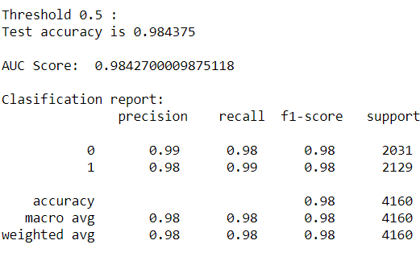

```python
Image(filename=os.path.join(OUTPUT_DIR,"lgb_tfidf_report.png"))
```

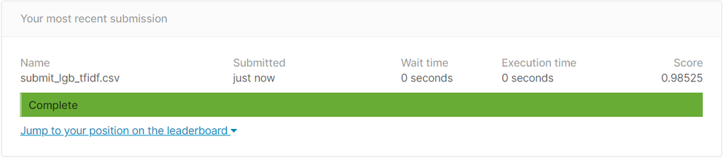

```python
Image(filename=os.path.join(OUTPUT_DIR,"submit_lgb_tfidf.png"))
```

#### XGBoost

```python
model_xgb = run_xgb(train_transform, y_train, test_transform, y_test)
n_rounds = model_xgb.best_ntree_limit
gc.collect()
```

```python
###############################################################################################################
# Prediction on Validation set to check the threshold:
###############################################################################################################
prob_validation = model_xgb.predict(xgb.DMatrix(test_transform), ntree_limit = n_rounds)
prob_validation = pd.DataFrame(prob_validation, columns = ["label"])
```

```python
###############################################################################################################
# Confusion Matrix:
###############################################################################################################
predictions_scores(prob_validation, pd.DataFrame(y_test, columns = ["label"]), "label") # 0.50
```

```
######################## label #############################
Threshold 0.1 :
Test accuracy is 0.9721153846153846

AUC Score:  0.9986512485317411

Clasification report:
               precision    recall  f1-score   support

           0       1.00      0.95      0.97      2031
           1       0.95      1.00      0.97      2129

    accuracy                           0.97      4160
   macro avg       0.97      0.97      0.97      4160
weighted avg       0.97      0.97      0.97      4160



Threshold 0.15 :
Test accuracy is 0.9754807692307692

AUC Score:  0.9986512485317411

Clasification report:
               precision    recall  f1-score   support

           0       0.99      0.96      0.97      2031
           1       0.96      0.99      0.98      2129

    accuracy                           0.98      4160
   macro avg       0.98      0.98      0.98      4160
weighted avg       0.98      0.98      0.98      4160



Threshold 0.2 :
Test accuracy is 0.9774038461538461

AUC Score:  0.9986512485317411

```

[output cut: 249 more lines]

```

Threshold 0.95 :
Test accuracy is 0.9574519230769231

AUC Score:  0.9986512485317411

Clasification report:
               precision    recall  f1-score   support

           0       0.92      1.00      0.96      2031
           1       1.00      0.92      0.96      2129

    accuracy                           0.96      4160
   macro avg       0.96      0.96      0.96      4160
weighted avg       0.96      0.96      0.96      4160
```

```python
###############################################################################################################
# Prediction on Test set
###############################################################################################################

prob_test = model_xgb.predict(xgb.DMatrix(sub_transform), ntree_limit = n_rounds)

# Apply threshold :

prob_test = [1 if pred > 0.5 else 0 for pred in prob_test]
prob_test = pd.DataFrame(prob_test, columns = ["label"])


sub_test_df = pd.concat([test_df["id"], prob_test["label"]], axis=1)
sub_final_df = pd.merge(sub_df["id"], sub_test_df, how = "left").fillna(1)
```

```python
save_dataframe(sub_final_df, os.path.join(OUTPUT_DIR,"submit_xgb_tfidf.csv"))
```

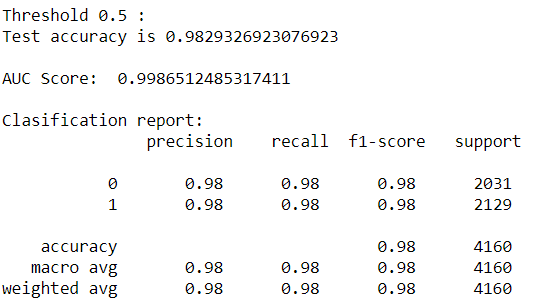

```python
Image(filename=os.path.join(OUTPUT_DIR,"xgb_tfidf_report.png"))
```

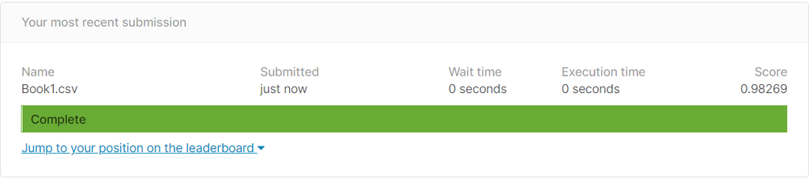

```python
Image(filename=os.path.join(OUTPUT_DIR,"submit_xgb_tfidf.png"))
```

### Text Classification (Word2Vec + LightGBM) & Kaggle Leaderboard Scores

```python
word2vec = EmbeddingTransformer('word2vec')
```

```
[==================================================] 100.0% 1662.8/1662.8MB downloaded
```

```python
X_train_embeddings = word2vec.transform(X_train["combined_clean_title_text"].tolist())
X_test_embeddings = word2vec.transform(X_test["combined_clean_title_text"].tolist())
sub_test_embeddings = word2vec.transform(test_df["combined_clean_title_text"].tolist())
```

```python
model_lgb = lgb.LGBMClassifier(random_state=0).fit(X_train_embeddings, y_train)
```

```python
###############################################################################################################
# Prediction on Validation set to check the threshold:
###############################################################################################################
prob_validation = model_lgb.predict(X_test_embeddings)
prob_validation = pd.DataFrame(prob_validation, columns = ["label"])
```

```python
###############################################################################################################
# Confusion Matrix:
###############################################################################################################
predictions_scores(prob_validation, pd.DataFrame(y_test, columns = ["label"]), "label") # 0.50
```

```python
###############################################################################################################
# Prediction on Test set
###############################################################################################################

prob_test = model_lgb.predict(sub_test_embeddings)

# Apply threshold :

prob_test = [1 if pred > 0.5 else 0 for pred in prob_test]
prob_test = pd.DataFrame(prob_test, columns = ["label"])


sub_test_df = pd.concat([test_df["id"], prob_test["label"]], axis=1)
sub_final_df = pd.merge(sub_df["id"], sub_test_df, how = "left").fillna(1)
```

```python
save_dataframe(sub_final_df, os.path.join(OUTPUT_DIR,"submit_lgb_word2vec.csv"))
```

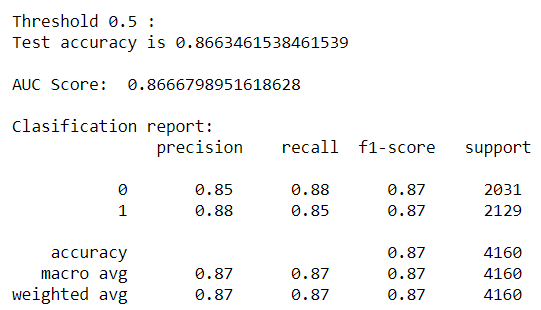

```python
Image(filename=os.path.join(OUTPUT_DIR,"lgb_word2vec_report.png"))
```

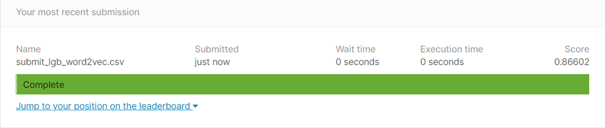

```python
Image(filename=os.path.join(OUTPUT_DIR,"submit_lgb_word2vec.png"))
```

### Text Classification (Glove + LightGBM) & Kaggle Leaderboard Scores

```python
glove = EmbeddingTransformer('glove')
```

```
[==================================================] 100.0% 104.8/104.8MB downloaded
```

```python
X_train_embeddings = glove.transform(X_train["combined_clean_title_text"].tolist())
X_test_embeddings = glove.transform(X_test["combined_clean_title_text"].tolist())
sub_test_embeddings = glove.transform(test_df["combined_clean_title_text"].tolist())
```

```python
model_lgb = lgb.LGBMClassifier(random_state=0).fit(X_train_embeddings, y_train)
```

```python
###############################################################################################################
# Prediction on Validation set to check the threshold:
###############################################################################################################
prob_validation = model_lgb.predict(X_test_embeddings)
prob_validation = pd.DataFrame(prob_validation, columns = ["label"])
```

```python
###############################################################################################################
# Confusion Matrix:
###############################################################################################################
predictions_scores(prob_validation, pd.DataFrame(y_test, columns = ["label"]), "label") # 0.50
```

```python
###############################################################################################################
# Prediction on Test set
###############################################################################################################

prob_test = model_lgb.predict(sub_test_embeddings)

# Apply threshold :

prob_test = [1 if pred > 0.5 else 0 for pred in prob_test]
prob_test = pd.DataFrame(prob_test, columns = ["label"])


sub_test_df = pd.concat([test_df["id"], prob_test["label"]], axis=1)
sub_final_df = pd.merge(sub_df["id"], sub_test_df, how = "left").fillna(1)
```

```python
save_dataframe(sub_final_df, os.path.join(OUTPUT_DIR,"submit_lgb_glove.csv"))
```

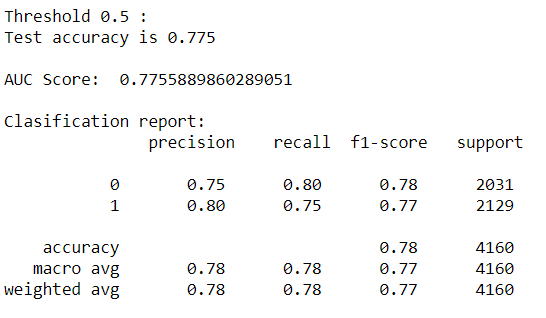

```python
Image(filename=os.path.join(OUTPUT_DIR,"lgb_glove_report.png"))
```

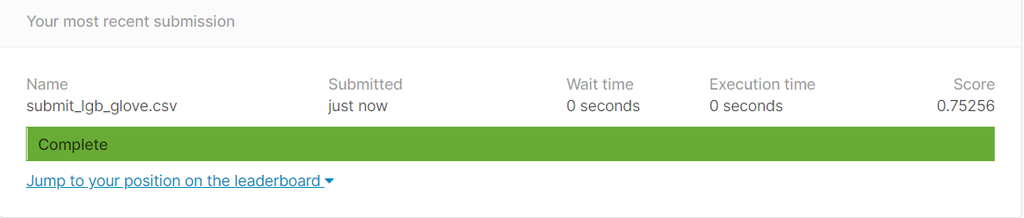

```python
Image(filename=os.path.join(OUTPUT_DIR,"submit_lgb_glove.png"))
```

### Text Classification (FastText + LightGBM) & Kaggle Leaderboard Scores

```python
fasttext = EmbeddingTransformer('fasttext')
```

```
[==================================================] 100.0% 958.5/958.4MB downloaded
```

```python
X_train_embeddings = fasttext.transform(X_train["combined_clean_title_text"].tolist())
X_test_embeddings = fasttext.transform(X_test["combined_clean_title_text"].tolist())
sub_test_embeddings = fasttext.transform(test_df["combined_clean_title_text"].tolist())
```

```python
model_lgb = lgb.LGBMClassifier(random_state=0).fit(X_train_embeddings, y_train)
```

```python
###############################################################################################################
# Prediction on Validation set to check the threshold:
###############################################################################################################
prob_validation = model_lgb.predict(X_test_embeddings)
prob_validation = pd.DataFrame(prob_validation, columns = ["label"])
```

```python
###############################################################################################################
# Confusion Matrix:
###############################################################################################################
predictions_scores(prob_validation, pd.DataFrame(y_test, columns = ["label"]), "label") # 0.50
```

```python
###############################################################################################################
# Prediction on Test set
###############################################################################################################

prob_test = model_lgb.predict(sub_test_embeddings)

# Apply threshold :

prob_test = [1 if pred > 0.5 else 0 for pred in prob_test]
prob_test = pd.DataFrame(prob_test, columns = ["label"])


sub_test_df = pd.concat([test_df["id"], prob_test["label"]], axis=1)
sub_final_df = pd.merge(sub_df["id"], sub_test_df, how = "left").fillna(1)
```

```python
save_dataframe(sub_final_df, os.path.join(OUTPUT_DIR,"submit_lgb_fasttext.csv"))
```

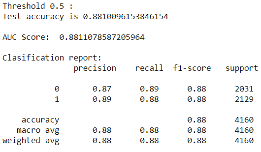

```python
Image(filename=os.path.join(OUTPUT_DIR,"lgb_fasttext_report.png"))
```

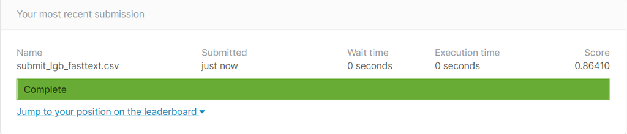

```python
Image(filename=os.path.join(OUTPUT_DIR,"submit_lgb_fasttext.png"))
```

### Further Improvements

1. Hyperparameter Tunning of ensemble models
2. Stacking & Ensembling of different models (Logistic, Decision Tree, Random Forest, GBM, XGBoost, Lightgbm)
3. Stack TF-IDF features & Word2vec/Glove/Fasttext embeddings
4. Creation of sentence embedding vectors of text based features to capture the semantics info sentence transformers